# Exploring cognitive intervention impacts on Reasoning from the ACTIVE study.

Author

Katelyn McClure and Alicia Severiano Perez

Published

November 6, 2025

Abstract

The ability to reason is critical for navigating everyday life in older adults. The ACTIVE study investigated whether cognitive interventions targeting reasoning and memory could improve cognitive performance over time. Using a GEE model to account for repeated measures within individuals, we explored whether reasoning scores differed after 3 years of interventions compared to baseline. Our analysis shows that all interventions have positive effects on reasoning scores, but particularly, the reasoning-focused intervention produces the best improvement. Our findings suggest that the targeted cognitive training can have long-term benefits for older adults, which can help them navigate their lives more smoothly.

## Introduction

The ACTIVE (Advanced Cognitive Training for Independent and Vital Elderly) study was a large research project from the 1990s-2000s that looked at whether specific types of cognitive training could help older adults stay mentally sharp and independent as they aged (Tennstedt and Unverzagt 2013; Rebok et al. 2014). Researchers randomly assigned over 2,800 healthy participants, all aged 65 or older, to one of four groups - memory training, reasoning training, speed of processing training, or a control group that did not receive any training (Tennstedt and Unverzagt 2013). The researchers found that these targeted interventions led to improvements in the specific skills being trained, and in some cases, the benefits lasted for years (Rebok et al. 2014).

In our analysis, we focus on finding if the reasoning score average changes after three years for the different training groups tend to differ from the control group’s scores before three years, while accounting for baseline age and gender. This question is important because reasoning ability plays a key role in maintaining independence and quality of life for older adults. Understanding how demographic and treatment factors influence reasoning can help identify which populations benefit most from targeted cognitive training and how those effects change over the long-term. By using generalized estimating equations (GEE), we aim to model population-level patterns of reasoning and better understand the lasting effects of cognitive intervention in aging populations.

## Data

Our data comes from a large longitudinal study of over 2,800 healthy older adults who were randomly assigned to one of several cognitive training groups or a no-training control group. For our analysis, we focus on comparing participants in the reasoning training group to those in the non-reasoning groups, combining the memory and speed-of-processing training groups into a single “Other” category to simplify interpretation. Participants completed repeated assessments of their cognitive performance over several years, allowing researchers to track changes in specific abilities such as reasoning. The overall reasoning score is calculated from participants’ performance in three tests that involved serial patterns of words and letters. Because each participant contributed multiple observations over the ten years of the study, the data from the same person is correlated. Our data also includes demographic information such as age at baseline and binary gender. We wrangled baseline age into three categories: those 65-74 years old, those 75-84 years old, and those 85+ years old.

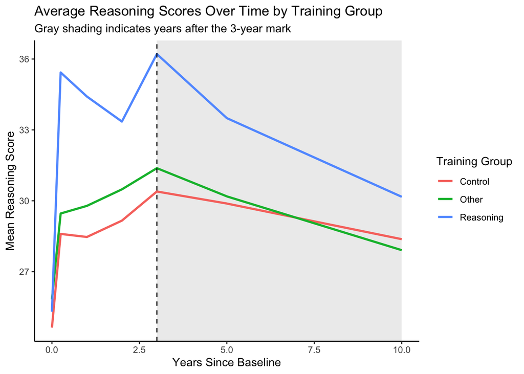

## Methods

To evaluate changes in reasoning performance over time and across training groups, we used a generalized estimating equation (GEE) framework. GEE models are well suited for longitudinal data because they account for the within-subject correlation of repeated measures without requiring assumptions about individual-specific random effects (Liang and Zeger 1986). Our mean model specified Reasoning Score as the dependent variable and included explanatory variables for Years since baseline, an indicator for whether the assessment occurred after the three-year mark, trial group, gender, and age at baseline. Interaction terms between Years, the post–three-year indicator, and trial group allowed us to test whether reasoning score trends differed between the reasoning training and control groups before and after the three-year mark.

We compared multiple correlation structures for our GEE model, including autoregressive (AR1) and exchangeable, and selected the exchangeable correlation structure based on the similarity between its model-based and robust standard errors. Smaller differences between these estimates suggest that the chosen structure appropriately reflects the correlation among repeated observations within individuals, as robust standard errors do not rely on the correlation structure marked, while the model standard errors do. The exchangeable structure assumes a constant correlation among repeated reasoning scores for each participant.

Statistical inference for model parameters was based on Wald tests, which evaluate whether one or more coefficients differ significantly from zero (Wald 1943). In our analysis, Wald tests were used to assess the significance of group-related effects and interactions in the model, including comparisons of reasoning scores between training groups and the control group at different time points, while accounting for within-subject correlation.

Model estimation was conducted in R using the geeM package (McDaniel, Henderson, and Rathouz 2013), which provides a fast implementation of GEE models. The resulting coefficients describe average population-level effects, aligning with our goal of understanding the overall impact of reasoning training across older adults rather than subject-specific trajectories. The tidyverse package was used for data wrangling and visualizations (Wickham et al. 2019).

## Results

Our GEE model showed that the residuals were on average close to 0, particularly for the Other and Control groups. Indicating that the model was somewhat a good fit. For the Reasoning training group, however, the residuals seemed to fluctuate in a wave-like pattern over time, suggesting that there is some variability in how the GEE model fits this groups reasoning scores. There also seemed to be some very clear patterns of how the residuals were distributed and thus due to unrandomness, this suggests the model might have missed some patterns

Based on our chosen GEE model, we had a baseline representing reasoning scores at Year 0 (before the 3-year mark) for females aged between 65 and 74 years in the control group. Upon examining the model estimates, we found that at baseline, reasoning scores decreased as age increased. For example, participants aged 85 and above scored approximately 13 points lower than those in the baseline age group. We also found that when comparing scores after Year 3, the scores were on average 3.92 points higher than at baseline. Additionally, we found that when comparing baseline to when we did have the score be evaluated after Year 3, both the Other and Reasoning groups, who were treated in some way, performed slightly better than the Control group, who were tested before Year 3.

When evaluating the 3-way interaction through the Wald test, we found that the effect of each additional year on reasoning scores after year 3 varied based on the training group. In other words, the slope of Years was not the same across each training group. Particularly, the Reasoning training group showed a significant decrease after year 3, while the other group showed a very small and non-significant decrease in reasoning scores.

We also ran a Wald test to compare the average reasoning scores for the Reasoning training group after Year 3 with the control group baseline. We found statistically significant results, indicating that the Reasoning training group had higher reasoning scores compared to the Control basline. We also compared the average reasoning scores of the Other treatment group after Year 3 to the baseline scores of the Control group. This comparison also showed a statistically significant difference, where the Other training groups had higher reasoning scores after 3 years compared to the Control’s baseline.

Lastly, we used the Wald test to compare the slopes of the reasoning scores for each the reasoning and other training group against the control group. Particularly, for the reasoning training group, we found statistically significant results indicating that the the slope for the Reasoning training group was lower than that of the control group, indicating that reasoning scores decline faster after Year 3 compared to the control group. On the other hand, we didn’t find statistically significant results that would lead us to believe that the slope was different between the trial and control group after 3 years of the initial intervention.

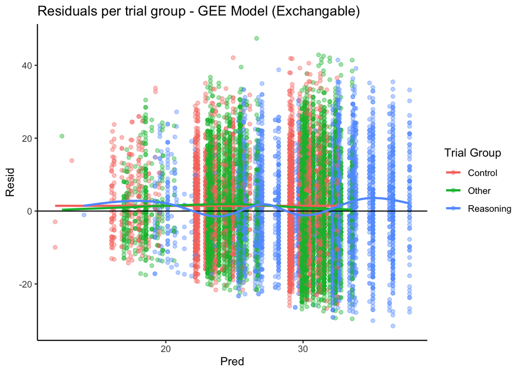

## Conclusions

Our research goal was to determine whether the reasoning scores differed between the Control group at baseline and the scores after 3 years for the Other and Reasoning training groups. From our analysis, we found that overall reasoning scores for both the Reasoning and Other training groups were, on average, significantly higher than the Control at baseline. Notably, the Reasoning group showed the largest positive impact on reasoning scores, compared to both the Other and Control groups. This suggests that the reasoning cognitive intervention had strong and lasting positive effects. We make this conclusion, as in baseline, we seek scores of individuals without any sort of intervention, even if it’s a Control group with no intervention. Thus the fact that the scores are higher after years with the reasoning intervention indicates that there was positive effects. The improvements observed in the other training group suggest that the cognitive interventions that focused on memory and processing speed also provided long term benefits to reasoning performance.

This conclusion is supported by the fact that baseline scores reflect individuals without intervention before any individual started being treated, so the higher scores resulting after 3 years in the Reasoning group indicate meaningful impacts. Furthermore, we accounted for differences in gender and baseline age, which further supports the effectiveness of the intervention.

However, there are some limitations of this project that should be noted. Particularly, we assumed our correlation structure to be ‘exchangeable’ in the GEE model, which may not perfectly reflect true correlation over time. Though we disregarded the autoregressive correlation structure at lag 1, due to small differences, the changes in this assumption could influence the results. Additionally, it is important to highlight our residuals from our model, as they didn’t seem randomly distributing, indicating that there may be patterns our model didn’t account for.

All in all, based on the analysis the ACTIVE demonstrates that cognitive training can be meaningful and have positive long term impacts on reasoning abilities in older adults.

## Acknowledgements

Thank you to Dr. Brianna Heggeseth for providing a clean and comprehensible ACTIVE Study dataset for us to use in our analysis. Also, a huge thank you to the Correlated Data Notes, written by Dr. Heggeseth, for guiding us in understanding different concepts and interpreting results.

## References

Liang, Kung-Yee, and Scott L Zeger. 1986. “Longitudinal Data Analysis Using Generalized Linear Models.” *Biometrika* 73 (1): 13–22.

McDaniel, Lee S., Nicholas C. Henderson, and Paul J. Rathouz. 2013. “Fast Pure R Implementation of GEE: Application of the Matrix Package.” *The R Journal* 5: 181–87. https://journal.r-project.org/archive/2013-1/mcdaniel-henderson-rathouz.pdf.

Rebok, George W, Karlene Ball, Lin T Guey, Richard N Jones, Hae-Young Kim, Jonathan W King, Michael Marsiske, et al. 2014. “Ten-Year Effects of the ACTIVE Cognitive Training Trial on Cognition and Everyday Functioning in Older Adults.” *Journal of the American Geriatrics Society* 62 (1): 16.

Tennstedt, Sharon L, and Frederick W Unverzagt. 2013. “The ACTIVE Study: Study Overview and Major Findings.” *Journal of Aging and Health*. Sage Publications Sage CA: Los Angeles, CA.

Wald, Abraham. 1943. “Tests of Statistical Hypotheses Concerning Several Parameters When the Number of Observations Is Large.” *Transactions of the American Mathematical Society* 54 (3): 426–82.

Wickham, Hadley, Mara Averick, Jennifer Bryan, Winston Chang, Lucy D’Agostino McGowan, Romain François, Garrett Grolemund, et al. 2019. “Welcome to the Tidyverse.” *Journal of Open Source Software* 4 (43): 1686. https://doi.org/10.21105/joss.01686.